A couple of reminders ( **for myself** ) to keep in mind when using *iPython notebooks*:

1- When starting a new notebook session, make sure you run all of the cells up to the point where you last left. use # to determine headers like

# header 1

## header 2

### header 3

and so on.

2- For italics, wrap the text in one asterisk or underscore, *iPython notebooks* or *iPython notebooks*.

3- Bold text uses two symbols, **iPython notebooks** or **iPython notebooks**.

# P2: Investigate a Dataset.

## Data Dictionary

**Variable, Definition, Key**

*survival* Survival 0 = No, 1 = Yes *pclass Ticket* class 1 = 1st, 2 = 2nd, 3 = 3rd *sex* Sex  
*Age* Age in years  
*sibsp* # of siblings / spouses aboard the Titanic  
*parch* # of parents / children aboard the Titanic  
*ticket* Ticket number  
*fare* Passenger fare  
*cabin* Cabin number  
*embarked* Port of Embarkation C = Cherbourg, Q = Queenstown, S = Southampton

**Variable Notes**

*pclass*: A proxy for socio-economic status (SES) 1st = Upper 2nd = Middle 3rd = Lower

*age:* Age is fractional if less than 1. If the age is estimated, is it in the form of xx.5

*sibsp:* The dataset defines family relations in this way... Sibling = brother, sister, stepbrother, stepsister Spouse = husband, wife (mistresses and fiancés were ignored)

*parch:* The dataset defines family relations in this way... Parent = mother, father Child = daughter, son, stepdaughter, stepson Some children travelled only with a nanny, therefore parch=0 for them.

#### 1- what questions you could answer using dataset of Titanic (brainstorming)

**Q1:** what are the survived ratios of female and male passengers?*

**Q1.1:** Did there childens passengers on titanic? and how many of them ? what is their ratio ?*

**Q1.2** Is the ratio survived affected by age range?*

**Q1.3:** Is there a relationship between adult/child and surviving?

**Q1.4:** Is the survival rate affected by gender?

**Q2:** Is there a reason of family to be most survived as they were helping each other to survive naturally?

### 1- Read dataset from train.csv

```python
# to read dataset titanic-data.csv
#import unicodecsv

#with open('titanic_data.csv', 'rb') as f:
#    reader = unicodecsv.DictReader(f)
#    titanic_data = list(reader)
# printing first record
#titanic_data[0]
# printing all record
#print(*ti_data, sep=', ')

import pandas as pd
import numpy as np
import matplotlib.pyplot as plt
import seaborn as sns

titanic_data=pd.read_csv('train.csv')
```

## First describing the dataset

```python
titanic_data.describe()
```

|  | PassengerId | Survived | Pclass | Age | SibSp | Parch | Fare |
| --- | --- | --- | --- | --- | --- | --- | --- |
| count | 891.000000 | 891.000000 | 891.000000 | 714.000000 | 891.000000 | 891.000000 | 891.000000 |
| mean | 446.000000 | 0.383838 | 2.308642 | 29.699118 | 0.523008 | 0.381594 | 32.204208 |
| std | 257.353842 | 0.486592 | 0.836071 | 14.526497 | 1.102743 | 0.806057 | 49.693429 |
| min | 1.000000 | 0.000000 | 1.000000 | 0.420000 | 0.000000 | 0.000000 | 0.000000 |
| 25% | 223.500000 | 0.000000 | 2.000000 | 20.125000 | 0.000000 | 0.000000 | 7.910400 |
| 50% | 446.000000 | 0.000000 | 3.000000 | 28.000000 | 0.000000 | 0.000000 | 14.454200 |
| 75% | 668.500000 | 1.000000 | 3.000000 | 38.000000 | 1.000000 | 0.000000 | 31.000000 |
| max | 891.000000 | 1.000000 | 3.000000 | 80.000000 | 8.000000 | 6.000000 | 512.329200 |

### Detect missing data by getting the number \ percentage of missing values in each columns

```python
def getPtMissing(series):
    num = series.isnull().sum()
    return (num/891)*100

def getNbMissing(series):
    num = series.isnull().sum()
    return (num)

def getNbUnMissing(series):
    num = series.notnull().sum()
    return (num)

print (('percentage of missing values in each col \n{}%'.format(titanic_data.apply(getPtMissing))))
print (('Number of missing values in each col \n{}%'.format(titanic_data.apply(getNbMissing))))
print (('number of clear values in each col \n{}'.format(titanic_data.apply(getNbUnMissing))))

#num_of_missing_age = sum(pd.isnull(titanic_data['Age']))
#num_of_missing_cabin = sum(pd.isnull(titanic_data['Cabin']))
#print (train.fillna('NaN').count())
```

```
percentage of missing values in each col
PassengerId     0.000000
Survived        0.000000
Pclass          0.000000
Name            0.000000
Sex             0.000000
Age            19.865320
SibSp           0.000000
Parch           0.000000
Ticket          0.000000
Fare            0.000000
Cabin          77.104377
Embarked        0.224467
dtype: float64%
Number of missing values in each col
PassengerId      0
Survived         0
Pclass           0
Name             0
Sex              0
Age            177
SibSp            0
Parch            0
Ticket           0
Fare             0
Cabin          687
Embarked         2
dtype: int64%
number of clear values in each col
PassengerId    891
Survived       891
Pclass         891
Name           891
Sex            891
Age            714
SibSp          891
Parch          891
Ticket         891
Fare           891
Cabin          204
Embarked       889
dtype: int64
```

###### All columns are fill properly with no missing data except Age, Cabin and Embarked with 19.87, 77.10 and 0.22 respectively.

###### So, the most missing values are in Cabin column with 77.10%. I'm sure it wouldn't affect the result weather contains NaN or not. Might be the only thing I would be thinking about if that column was not containing missing values is that which cabins were more likely to be safe than other. So, I'm wondering if the data in cabin column is complete I might find some interesting relationship in between cabins and survived passengers.

### 2- Cleaning up and analyzing data

### Trying to clean mising values in Age column to get the exact describtion of column data and create plot.

```python
clean_data_Age=titanic_data.dropna(subset=['Age'])

def describe_data(x):
    print ('mean age:', np.mean(x))
    print ('maximum age:', np.max(x))
    print ('minimum age:', np.min(x))
    print ('sd:', np.std(x))

describe_data(clean_data_Age['Age'])
# %matplotlib inline
#
# plt.hist(clean_data_Age['Age'])
# plt.ylabel("Total number")
# plt.xlabel("Age")
# plt.title("Age range")
```

```
mean age: 29.69911764705882
maximum age: 80.0
minimum age: 0.42
sd: 14.516321150817317
```

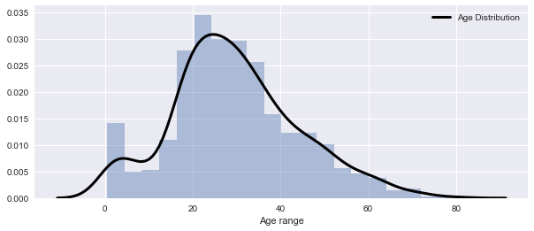

```python
sns.set(rc={"figure.figsize": (10, 4)});
x = clean_data_Age['Age']
ax = sns.distplot(x, axlabel='Age range', kde_kws={"color": "k", "lw": 3, "label": "Age Distribution"})
```

###### Most passengers are in age range between 18 and 40 years old also most of them are adults.

```
mean age: 0.3838383838383838
maximum age: 1
minimum age: 0
sd: 0.48631931786710086
```

[output not shown]

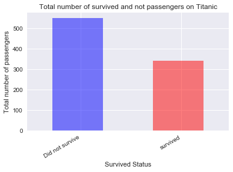

```python
describe_data(titanic_data['Survived'])

%matplotlib inline
fig, axs = plt.subplots(1)
titanic_data.groupby('Survived')['PassengerId'].count().plot(alpha=0.5,kind='bar',title="Total number of survived and not passengers on Titanic", color='b''r');
plt.ylabel("Total number of passengers")
plt.xlabel("Survived Status")

fig.autofmt_xdate(bottom=0.2, rotation=30, ha='right') # rotate xticks to fit plot frame.

index = np.arange(2)
plt.xticks(index + .35/12.50, ('Did not survive', 'survived'))
```

##### histogram above shows that more than 500 passengers died where 0 indicates to not survived and 1 survived. No need to clean data in this column as it is clean and no missing values existed.

```python
# dropping all records contain NaN cells ( missing values )
clean_records=titanic_data.dropna().head()
# Counting the number of records with no missing values
num_clean_records=titanic_data.dropna().head().count()
# counting total recordes of titanic_data.csv
num_full_records1=titanic_data.count()
num_full_records=len(titanic_data)
# total number of unclean records (contain null cells ( missing values ))
num_unclean_records=num_full_records - num_clean_records
#df.replace(r'\s+', np.nan, regex=True)
#titanic_data.dropna(subset="Cabin")
```

```python
clean_records
```

|  | PassengerId | Survived | Pclass | Name | Sex | Age | SibSp | Parch | Ticket | Fare | Cabin | Embarked |
| --- | --- | --- | --- | --- | --- | --- | --- | --- | --- | --- | --- | --- |
| 1 | 2 | 1 | 1 | Cumings, Mrs. John Bradley (Florence Briggs Th... | female | 38.0 | 1 | 0 | PC 17599 | 71.2833 | C85 | C |
| 3 | 4 | 1 | 1 | Futrelle, Mrs. Jacques Heath (Lily May Peel) | female | 35.0 | 1 | 0 | 113803 | 53.1000 | C123 | S |
| 6 | 7 | 0 | 1 | McCarthy, Mr. Timothy J | male | 54.0 | 0 | 0 | 17463 | 51.8625 | E46 | S |
| 10 | 11 | 1 | 3 | Sandstrom, Miss. Marguerite Rut | female | 4.0 | 1 | 1 | PP 9549 | 16.7000 | G6 | S |
| 11 | 12 | 1 | 1 | Bonnell, Miss. Elizabeth | female | 58.0 | 0 | 0 | 113783 | 26.5500 | C103 | S |

##### Conclusion:

```python
print ('total records in titanic_data.csv {} ,\n clean records = {},\n unclean records = {}'.format(num_full_records,num_clean_records,num_unclean_records ))
```

```
total records in titanic_data.csv 891 ,
 clean records = PassengerId    5
Survived       5
Pclass         5
Name           5
Sex            5
Age            5
SibSp          5
Parch          5
Ticket         5
Fare           5
Cabin          5
Embarked       5
dtype: int64,
 unclean records = PassengerId    886
Survived       886
Pclass         886
Name           886
Sex            886
Age            886
SibSp          886
Parch          886
Ticket         886
Fare           886
Cabin          886
Embarked       886
dtype: int64
```

```python
number_of_passengers=titanic_data['Survived'].count()
number_of_servived=titanic_data['Survived'].sum()
percentage_of_servived= (number_of_servived/number_of_passengers)*100

print ('number of passengers = {}'.format(number_of_passengers))
print ('number of servived passengers = {}'.format(number_of_servived))
print ('number of died passengers = {}'.format(number_of_passengers-number_of_servived))
print ('percentage of servived passengers = {}%'.format(percentage_of_servived))
```

```
number of passengers = 891
number of servived passengers = 342
number of died passengers = 549
percentage of servived passengers = 38.38383838383838%
```

##### Instead of using $(0.383838 * 100)-891 $ formela to chaculate the total number of Survived passengers; where 0.383838 is the mean of column survived. I used .sum() to sum all the values in column Survived where the exist value are 1 for survived and 0 for not survived and I found 342 passengers are survived. Results here validate my observation through the histogram in figure (2) above.

##### Then .count() to count the total of passengers either survived or not, which there are 891 passengers exist.

##### finally, I got the percentage of servived passengers = 38.38%

## Anwsering some of previous questions.

**Q1:** what are the survived ratios of female and male passengers?*

**Q1.1:** Did there childens passengers travel on titanic? and how many of them ? what is their ratio ?*

**Q1.2** Is the percentage of survived affected by age range?*

**Q1.3:** Is there a relationship between adult/child and surviving?

**Q1.4:** Is the survival rate affected by gender?

## Correlation Coefficient

Note for myself: •A correlation coefficient of 1 means that for every positive increase of 1 in one variable, there is a positive increase of 1 in the other. •A correlation coefficient of -1 means that for every positive increase of 1 in one variable, there is a negative decrease of 1 in the other. •Zero means that for every increase, there isn’t a positive or negative increase. The two just aren’t related.

```python
def corr(data1, data2):
    "data1 & data2 should be numpy arrays."
    mean1 = data1.mean()
    mean2 = data2.mean()
    std1 = data1.std()
    std2 = data2.std()

#   corr = ((data1-mean1)*(data2-mean2)).mean()/(std1*std2)
    corr = ((data1*data2).mean()-mean1*mean2)/(std1*std2)
    return corr


corr(clean_data_Age['Age'], clean_data_Age['Survived'])
```

```
-0.07711294177865867
```

```python
titanic_data.ix[(titanic_data.Sex == 'female') , 'Sex'] = 0
titanic_data.ix[(titanic_data.Sex == 'male' ) , 'Sex'] = 1
```

```python
corr(titanic_data['Sex'], titanic_data['Survived'])
```

```
-0.54274155868170726
```

-0.54 is the correlation between sex and survived which indecats to mediam negative correclatin. As Sex column contains 1,0 values. 1 indecats to Adult males and boys where 0 indecats to Adult females and girls. on the other hands, As Survived column contains 1,0 values. 1 indecats to Survived where 0 indecats to Not survived.

thats mean, the percentage of survived female(0) is higher than male(1).

Let try discover it.

```python
# Return Sex column values to its origenal
titanic_data.ix[(titanic_data.Sex == 0 ) , 'Sex'] = 'female'
titanic_data.ix[(titanic_data.Sex == 1 ) , 'Sex'] = 'male'
```

```python
# calculate number of male/female passengers.

def getPercentage (value1):
    return (value1/total_of_passenger)*100

# #Im going to detect child passengers by there age and I will replace the corresponding value in sex column into child.

titanic_data.ix[(titanic_data.Age <= 18) & (titanic_data.Sex == 'female') , 'Sex'] = 'fchild'
titanic_data.ix[(titanic_data.Age <= 18) & (titanic_data.Sex == 'male') , 'Sex'] = 'mchild'


clean_data_Age=titanic_data.dropna(subset=['Age'])

total_of_passenger = len(clean_data_Age['PassengerId'])
number_of_male =len(clean_data_Age[(clean_data_Age['Sex']=='male')])
print (number_of_male)
number_of_female =len(clean_data_Age[(clean_data_Age['Sex']=='female')])

# calculate number of survived male/female passengers.
number_of_Survived_male =len(clean_data_Age[(clean_data_Age['Sex']=='male') & (clean_data_Age['Survived']==1)])
number_of_Survived_female =len(clean_data_Age[(clean_data_Age['Sex']=='female') & (clean_data_Age['Survived']==1)])
total_of_Survived=number_of_Survived_female+number_of_Survived_male

# calculate percentage of survived male/female passengers.
percentage_of_Survived_male= getPercentage(number_of_Survived_male)
percentage_of_Survived_female= getPercentage(number_of_Survived_female)

# calculate number of sink male/female passengers.
number_of_NotSurvived_male =len(clean_data_Age[(clean_data_Age['Sex']=='male') & (clean_data_Age['Survived']==0)])
number_of_NotSurvived_female =len(clean_data_Age[(clean_data_Age['Sex']=='female') & (clean_data_Age['Survived']==0)])
total_of_NotSurvived=number_of_NotSurvived_female+number_of_NotSurvived_male

# calculate percentage of sink male/female passengers.
percentage_of_NotSurvived_male= getPercentage(number_of_NotSurvived_male)
percentage_of_NotSurvived_female= getPercentage(number_of_NotSurvived_female)


print ('Total of passenger = {} where {} are female and {} are male with {}% and {}% respectively'
       .format(total_of_passenger
               ,number_of_female,number_of_male,
               getPercentage(number_of_female),
               getPercentage(number_of_male)))

print ('Total of sink passenger = {} where {} are female and {} are male with {}% and {}% respectively'
       .format(total_of_NotSurvived,number_of_NotSurvived_female,number_of_NotSurvived_male,
               percentage_of_NotSurvived_female,
               percentage_of_NotSurvived_male))


print ('Total of survived passenger = {} where {} are female and {} are male with {}% and {}% respectively'
       .format(total_of_Survived,number_of_Survived_female,number_of_Survived_male,
               percentage_of_Survived_female,
               percentage_of_Survived_male))
```

```
382
Total of passenger = 714 where 193 are female and 382 are male with 27.030812324929972% and 53.50140056022409% respectively
Total of sink passenger = 355 where 42 are female and 313 are male with 5.88235294117647% and 43.8375350140056% respectively
Total of survived passenger = 220 where 151 are female and 69 are male with 21.1484593837535% and 9.663865546218489% respectively
```

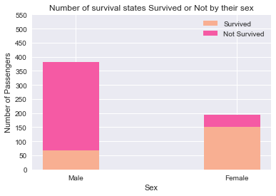

```python
def plotbarStacked (n,data1,data2,data3,data4,title,ylable,xlable,xticks1,xticks2,legend1,legend2,yticks1, yticks2, yticks3):
    N = n
    databar1 = (data1, data2)
    databar2 = (data3, data4)

    ind = np.arange(N)    # the x locations for the groups
    width = 0.35       # the width of the bars: can also be len(x) sequence

    p1 = plt.bar(ind, databar1, width, color='#F8AF92')
    p2 = plt.bar(ind, databar2, width, color='#F55AA4', bottom=databar1)

    plt.ylabel(ylable)
    plt.xlabel(xlable)
    plt.title(title)

    plt.xticks(ind + width/12.5, (xticks1, xticks2))
    plt.yticks(np.arange(yticks1, yticks2, yticks3))
    plt.legend((p1[0], p2[0]), (legend1, legend2))

def plotbarStacked1 (n,data1,data2,data3,data4,data5,data6,data7,data8,title,ylable,xlable,
                     xticks1,xticks2,xticks3,xticks4,legend1,legend2,yticks1, yticks2, yticks3):
    N = n
    databar1 = (data1, data2,data3,data4)
    databar2 = (data5, data6,data7,data8)


    ind = np.arange(N)    # the x locations for the groups
    width = 0.35       # the width of the bars: can also be len(x) sequence

    p1 = plt.bar(ind, databar1, width, color='#F8AF92')
    p2 = plt.bar(ind, databar2, width, color='#F55AA4', bottom=databar1)

    plt.ylabel(ylable)
    plt.xlabel(xlable)
    plt.title(title)

    plt.xticks(ind + width/12.50, (xticks1, xticks2,xticks3, xticks4))
    plt.yticks(np.arange(yticks1, yticks2, yticks3))
    plt.legend((p1[0], p2[0]), (legend1, legend2))

plotbarStacked (2,number_of_Survived_male,number_of_Survived_female,number_of_NotSurvived_male,number_of_NotSurvived_female,'Number of survival states ''Survived or Not'' by their sex','Number of Passengers','Sex','Male', 'Female','Survived', 'Not Survived',0,600,50)

##titanic_data.groupby(['Survived'])['PassengerId'].count().plot(kind='bar',title="Relation between passengers who survived depending on thier SITUATION ", color='y''m''c''b''r');
```

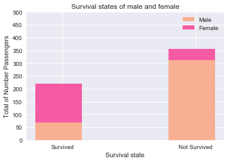

```python
plotbarStacked (2,number_of_Survived_male,number_of_NotSurvived_male,number_of_Survived_female,number_of_NotSurvived_female,'Survival states of male and female','Total of Number Passengers','Survival state','Survived', 'Not Survived','Male', 'Female',0,550,50)
```

##### In next piece of code, Im going to define the range of ages and gender:

```python
def getLen (gender,survived):
    x= len(titanic_data[(titanic_data['Sex']==gender) & (titanic_data['Survived']==survived)])
    return x


# calculate number of male/female passengers (Adult) girl/boy passengers (childern).
number_of_male =len(titanic_data[(titanic_data['Sex']=='male')])
number_of_mchild =len(titanic_data[(titanic_data['Sex']=='mchild')])
number_of_female =len(titanic_data[(titanic_data['Sex']=='female')])
number_of_fchild =len(titanic_data[(titanic_data['Sex']=='fchild')])

# calculate number of survived male/female passengers.
number_of_Survived_male = getLen ('male',1)
number_of_Survived_female = getLen ('female',1)
number_of_Survived_mchild = getLen ('mchild',1)
number_of_Survived_fchild = getLen ('fchild',1)

total_of_Survived_Adult= number_of_Survived_female+number_of_Survived_male
total_of_Survived_child=number_of_Survived_fchild+number_of_Survived_mchild

# calculate percentage of survived male/female passengers (Adult) girl/boy passengers (childern).
percentage_of_Survived_male= getPercentage(number_of_Survived_male)
percentage_of_Survived_female= getPercentage(number_of_Survived_female)
percentage_of_Survived_fchild= getPercentage(number_of_Survived_fchild)
percentage_of_Survived_mchild= getPercentage(number_of_Survived_mchild)

# calculate number of sink male/female passengers.
number_of_NotSurvived_male = getLen ('male',0)
number_of_NotSurvived_female = getLen ('female',0)
number_of_NotSurvived_mchild = getLen ('mchild',0)
number_of_NotSurvived_fchild = getLen ('mchild',0)


# calculate number of survived/ not survived adult passengers.
total_of_adult=number_of_female+number_of_male
total_of_Survived_adult=number_of_Survived_female+number_of_Survived_male
total_of_NotSurvived_Adult=number_of_NotSurvived_female+number_of_NotSurvived_male


# calculate number of survived adult passengers.
total_of_child=number_of_fchild+number_of_mchild
total_of_Survived_child=number_of_Survived_fchild+number_of_Survived_mchild
total_of_NotSurvived_child=number_of_NotSurvived_fchild+number_of_NotSurvived_mchild



print ('Total of passenger = {} where {} are female, {} are male, {} are girls and {} are boys with {}%,{}%,{}% and {}% respectively'
       .format(total_of_passenger
               ,number_of_female,number_of_male,
               number_of_fchild,number_of_mchild,
               getPercentage(number_of_female),
               getPercentage(number_of_male),
               getPercentage(number_of_fchild),
               getPercentage(number_of_mchild)))

print ('Total of sink passenger = {} where {} are female, {} are male, {} are girls and {} are boys'
       .format(total_of_NotSurvived,number_of_NotSurvived_female,number_of_NotSurvived_male,
               number_of_NotSurvived_fchild,
               number_of_NotSurvived_mchild))


print ('Total of survived passenger = {} where {} are female, {} are male, {} are girls and {} are boys'
       .format(total_of_Survived,number_of_Survived_female,number_of_Survived_male,
               number_of_Survived_fchild,
               number_of_Survived_mchild))
```

```
Total of passenger = 714 where 246 are female, 506 are male, 68 are girls and 71 are boys with 34.45378151260504%,70.86834733893558%,9.523809523809524% and 9.943977591036415% respectively
Total of sink passenger = 355 where 59 are female, 421 are male, 47 are girls and 47 are boys
Total of survived passenger = 220 where 187 are female, 85 are male, 46 are girls and 24 are boys
```

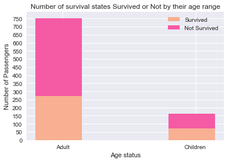

```python
plotbarStacked (2,total_of_Survived_adult,total_of_Survived_child,total_of_NotSurvived_Adult,
                total_of_NotSurvived_child,'Number of survival states ''Survived or Not'' by their age range',
                'Number of Passengers','Age status','Adult', 'Children','Survived', 'Not Survived',0,800,50)
```

#### So, less than 50% of adult passengers survived while around 50% of childrens survived.

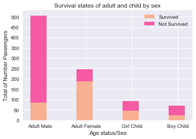

```python
plotbarStacked1 (4,number_of_Survived_male,number_of_Survived_female,
                 number_of_Survived_fchild,number_of_Survived_mchild,
                 number_of_NotSurvived_male,number_of_NotSurvived_female,
                 number_of_NotSurvived_fchild,number_of_NotSurvived_mchild,
                 'Survival states of adult and child by sex','Total of Number Passengers',
                 'Age status/Sex','Adult Male', 'Adult Female','Girl Child','Boy Child','Survived', 'Not Survived',0,550,50)
```

[figure not shown]

```python
import seaborn as sns
fig, axs = plt.subplots(1)
sns.barplot(data=titanic_data, x="Sex", hue='Sex', y='Survived', estimator=np.mean);
ind = np.arange(4)
plt.ylabel('proportion of survival');
plt.title('proportion of survival amonge genders')

plt.xticks(ind + 0.35/15.50, ('Male Adult', 'Female Adult','Girl Child', 'Boy Child'))
fig.autofmt_xdate(bottom=0.2, rotation=30, ha='right') # rotate xticks to fit plot frame.

plt.show()
```

###### Also, childs are most likely to be survived with percentage = 50% which considers as a high percentage comparing with the percentage of survived adults.

## **Q2:** Is there a reason of family surviving as they were helping each other to survive naturally?

## Correlation Coefficient

```python
np.corrcoef(titanic_data['Parch'], titanic_data['Survived'])[0, 1]
```

```
0.081629407083483485
```

```python
Survived_family_ds =titanic_data[(titanic_data['Parch']>0) & (titanic_data['Survived']==1)]

def number_of_survived_family():
    Survived_family =len(titanic_data[(titanic_data['Parch']>0) & (titanic_data['Survived']==1)])
    return Survived_family

def number_of_survived_single():
    Survived_single =len(titanic_data[(titanic_data['Parch']==0) & (titanic_data['Survived']==1)])
    return Survived_single

#number_of_singles = len(titanic_data[(titanic_data['Parch']==0)
#number_of_families = len(titanic_data[(titanic_data['Parch']>0)

single =(titanic_data['Parch']==0).sum()
family =(titanic_data['Parch']>0).sum()
number_of_survived_single=number_of_survived_single()
number_of_survived_family=number_of_survived_family()
number_of_Notsurvived_family=family-number_of_survived_family
number_of_Notsurvived_single=single-number_of_survived_single

print('total number of single passengers is {} but {} only are survived with {}%'.format (single,number_of_survived_single,(number_of_survived_single/single)*100))
print('total number of family passengers is {} but {} only are survived with {}%'.format (family,number_of_survived_family,(number_of_survived_family/family)*100))
```

```
total number of single passengers is 678 but 233 only are survived with 34.365781710914455%
total number of family passengers is 213 but 109 only are survived with 51.173708920187785%
```

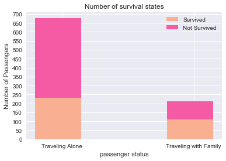

```python
plotbarStacked (2,number_of_survived_single,number_of_survived_family,number_of_Notsurvived_single,
                number_of_Notsurvived_family,'Number of survival states',
                'Number of Passengers','passenger status','Traveling Alone', 'Traveling with Family','Survived', 'Not Survived',0,750,50)
```

```python
def getLen2 (parch,survived):
    x= len(titanic_data[(titanic_data['Parch']==parch) & (titanic_data['Survived']==survived)])
    return x

single_Survived = getLen2 (0,1)
single_NotSurvived = getLen2 (0,0)
family_with_one = getLen2 (1,1)
family_with_one_NotSurvived = getLen2 (1,0)
family_with_two = getLen2 (2,1)
family_with_two_NotSurvived = getLen2 (2,0)
family_with_more_than_two =len(titanic_data[(titanic_data['Parch']> 2) & (titanic_data['Survived']==1)])
family_with_more_than_two_NotSurvived = len(titanic_data[(titanic_data['Parch']> 2) & (titanic_data['Survived']==0)])
```

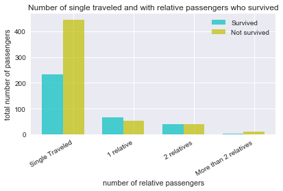

```python
n_groups = 4

means_survived = (single_Survived, family_with_one, family_with_two,family_with_more_than_two)

means_notsurvived = (single_NotSurvived, family_with_one_NotSurvived, family_with_two_NotSurvived,family_with_more_than_two_NotSurvived)


fig, axs = plt.subplots(1)

index = np.arange(n_groups)
bar_width = 0.35

opacity = 0.7
error_config = {'ecolor': '0.3'}

rects1 = plt.bar(index, means_survived, bar_width,
                 alpha=opacity,
                 color='c',
                 yerr=0,
                 error_kw=error_config,
                 label='Survived')

rects2 = plt.bar(index + bar_width, means_notsurvived, bar_width,
                 alpha=opacity,
                 color='y',
                 yerr=0,
                 error_kw=error_config,
                 label='Not survived')

plt.xlabel('number of relative passengers')
plt.ylabel('total number of passengers')
plt.title('Number of single traveled and with relative passengers who survived')
plt.xticks(index + bar_width, ('Single Traveled', '1 relative', '2 relatives', 'More than 2 relatives'))
fig.autofmt_xdate(bottom=0.2, rotation=30, ha='right') # rotate xticks to fit plot frame.
plt.legend()
plt.tight_layout()


plt.show()
```

#### most passengers are traveling alone with total number is 678 but only 233 are survived with 34.365781710914455%. However,

#### total number of family passengers is 213 but 109 only are survived with 51.173708920187785%

#### So, more than 50% of family passengers survived while less than 35% survived of single passengers .

###### Conclusin: Traveling alone survived passengers are more than family survived passengers with 233,109 out of 678 passengers. on the other hands, the percentage of family survived passengers is greater that singles with 51.17% of the total families. So, families are most likely to be survived than others passengers. ( it might be because the percentage of survived childers is higher than adult! ). its very clear that survived families with up to 3 people are very less.

### Statistical test:

For non-numerical data as our dataset, it doesn't follow the parameters of the normal distribution curve (Gaussian curve) The Mann-Whitney U test is an appropperate test, to a multiple group situation increases the possibility of incorrectly rejecting the null hypothesis.

```python
from scipy.stats import mannwhitneyu

mannwhitneyu(titanic_data['Age'], titanic_data['Survived'])
```

```
MannwhitneyuResult(statistic=3591.0, pvalue=2.1097827162090423e-298)
```

```python
mannwhitneyu(titanic_data['Parch'], titanic_data['Survived'])
```

```
MannwhitneyuResult(statistic=355716.0, pvalue=1.3969493070855283e-06)
```

#### statistic=3591.0 and 355716.0

#### pvalue=2.1097827162090423e-298 and 1.3969493070855283e-06 where less than 0.5

#### So, null hypothises is rejected.

## Conclusion

1. Total of passenger = 891 and only 342 passengers survived with 38.3% where most of them are female.
2. Most of families are survived but more than 50% of singles are sunked
3. High number of childern are survived where most of them are girls.

I'm not 100% sure that my views are correct as I have no idea of how data was collected.

Limitations:

1. if we have more information about families like specific columns of parants, child, number of survived passengers of each family and how many of them.
2. I don't know anything about the senario of survived and didn't survive passengers, how did thay survive! and how did thay die.
3. The dataset is less than 40% of the population where the other 60% might change the results.
4. Some passengers can swim so, they have chance to survived and getting/reaching the nearest lifeboat.
5. If we have full info of cabin column so, I can decied the position of crash.

References: 1- https://www.ncbi.nlm.nih.gov/pmc/articles/PMC3116565/

2- http://stackoverflow.com/questions/24852852/matplotlib-stacked-bar-graphs

3- http://matplotlib.org/api/colors_api.html

4- https://codeyarns.com/2014/10/27/how-to-change-size-of-matplotlib-plot/

5-http://pandas.pydata.org/pandas-docs/stable/reshaping.html

6- http://pandas.pydata.org/pandas-docs/stable/visualization.html